# assignment

2026-03-18

```r
suppressPackageStartupMessages({
  library(AnnotationHub)
  library(ensembldb)
  library(GenomicRanges)
  library(epiwraps)
  library(rtracklayer)
  library(ggplot2)
  library(magick)
})
ah <- AnnotationHub()
ensdb <- ah[["AH89211"]]

setwd("~/Desktop/ethEpigen2026_material/week04")
```

## Find and download from ENCODE the peaks (i.e. bed-like format) for p300, H3K27ac and H3K27me3 in mouse embryonic stem cells (mESC) and in one differentiated tissue (heart):

```r
options(timeout=1800)

download.file("https://www.encodeproject.org/files/ENCFF097ULJ/@@download/ENCFF097ULJ.bed.gz", "p300_heart.bed.gz") #2month old
R.utils::gunzip("p300_heart.bed.gz")

download.file("https://www.encodeproject.org/files/ENCFF653YVR/@@download/ENCFF653YVR.bed.gz", "p300_mESC.bed.gz")
R.utils::gunzip("p300_mESC.bed.gz")

download.file("https://www.encodeproject.org/files/ENCFF723ZZS/@@download/ENCFF723ZZS.bed.gz", "H3K27ac_heart.bed.gz")
R.utils::gunzip("H3K27ac_heart.bed.gz")

download.file("https://www.encodeproject.org/files/ENCFF212HAG/@@download/ENCFF212HAG.bed.gz", "H3K27ac_mESC.bed.gz")
R.utils::gunzip("H3K27ac_mESC.bed.gz")

download.file("https://www.encodeproject.org/files/ENCFF183KJW/@@download/ENCFF183KJW.bed.gz", "H3K27me3_heart.bed.gz")
R.utils::gunzip("H3K27me3_heart.bed.gz")

download.file("https://www.encodeproject.org/files/ENCFF105NKG/@@download/ENCFF105NKG.bed.gz", "H3K27me3_mESC.bed.gz")
R.utils::gunzip("H3K27me3_mESC.bed.gz")

#1.Create the folder
dir.create("peaks4")

#2.Move the .bed files into that folder
file.rename(list.files(pattern = "\\.bed$"),
            paste0("peaks4/", list.files(pattern = "\\.bed$")))
```

## Comparing the signals across the two tissues

### 1. What is the proportion of TSS that overlap H3K27ac, H3K27me3, and the combination of both, in each tissue?

```r
mouse_transcripts <- transcripts(ensdb)
tss <- promoters(mouse_transcripts, upstream = 0, downstream = 1)

#load the peaks
peakfiles <- list.files("peaks4", full.names = TRUE)
# then give them meaningful names
names(peakfiles) <- gsub("\\.bed","",basename(peakfiles))
# then loop through them and read them:
peaks <- lapply(peakfiles, FUN=rtracklayer::import, format="narrowPeak")
# peaks contains all the objects

#Force the Peaks to Ensembl Style
for(i in seq_along(peaks)) {
  #This converts "chr1" -> "1", "chrX" -> "X", etc.
  seqlevelsStyle(peaks[[i]]) <- "Ensembl"

  # Optional: Match the genome metadata exactly to the database
  #genome(peaks[[i]]) <- genome(ensdb)[1]
}

#Heart
num_tss_heart_H3K27ac <- sum(overlapsAny(tss, peaks$H3K27ac_heart))
num_tss_haert_H3K27me3 <- sum(overlapsAny(tss, peaks$H3K27me3_heart))
num_tss_heart_one <- sum(overlapsAny(tss, peaks$H3K27ac_heart) | overlapsAny(tss, peaks$H3K27me3_heart))
num_tss_heart_both <- sum(overlapsAny(tss, peaks$H3K27ac_heart) & overlapsAny(tss, peaks$H3K27me3_heart))
cat ("The proportion of TSS that overlap H3K27ac in heart:", round(num_tss_heart_H3K27ac/length(tss)*100) , "% \n")
cat ("The proportion of TSS that overlap H3K27me3 in heart:", round(num_tss_haert_H3K27me3/length(tss)*100), "% \n")
cat ("The proportion of TSS that overlap H3K27ac OR H3K27me3 in heart:", round(num_tss_heart_one/length(tss)*100), "% \n")
cat ("The proportion of TSS that overlap H3K27ac AND H3K27me3 in heart:", round(num_tss_heart_both/length(tss)*100), "% \n")
cat("\n")

#mESC
num_tss_mESC_H3K27ac <- sum(overlapsAny(tss, peaks$H3K27ac_mESC))
num_tss_mESC_H3K27me3 <- sum(overlapsAny(tss, peaks$H3K27me3_mESC))
num_tss_mESC_one <- sum(overlapsAny(tss, peaks$H3K27ac_mESC) | overlapsAny(tss, peaks$H3K27me3_mESC))
num_tss_mESC_both <- sum(overlapsAny(tss, peaks$H3K27ac_mESC) & overlapsAny(tss, peaks$H3K27me3_mESC))
cat ("The proportion of TSS that overlap H3K27ac in mESC:", round(num_tss_mESC_H3K27ac/length(tss)*100), "% \n")
cat ("The proportion of TSS that overlap H3K27me3 in mESC:", round(num_tss_mESC_H3K27me3/length(tss)*100), "% \n")
cat ("The proportion of TSS that overlap H3K27ac OR H3K27me3 in mESC:", round(num_tss_mESC_one/length(tss)*100), "% \n")
cat ("The proportion of TSS that overlap H3K27ac AND H3K27me3 in mESC:", round(num_tss_mESC_both/length(tss)*100), "% \n")
```

```
## The proportion of TSS that overlap H3K27ac in heart: 16 %
## The proportion of TSS that overlap H3K27me3 in heart: 2 %
## The proportion of TSS that overlap H3K27ac OR H3K27me3 in heart: 18 %
## The proportion of TSS that overlap H3K27ac AND H3K27me3 in heart: 0 %
##
## The proportion of TSS that overlap H3K27ac in mESC: 7 %
## The proportion of TSS that overlap H3K27me3 in mESC: 1 %
## The proportion of TSS that overlap H3K27ac OR H3K27me3 in mESC: 8 %
## The proportion of TSS that overlap H3K27ac AND H3K27me3 in mESC: 0 %
```

#### It is clear how TSS is low enriched of H3K27me3, indeed this is a repressive mark. In contrast, is it possible to see a significant percentage of TSS site entiched with the active H3K27ac mark. Also, we can’t find overlap between H3K27ac and H3K27me3, meaning that they could be mutually exclusive, reflective their opposite function.

### 2. What is the relationship between the 3 signals (p300, H3K27ac, and H3K27me3), and is it the same in both tissues?

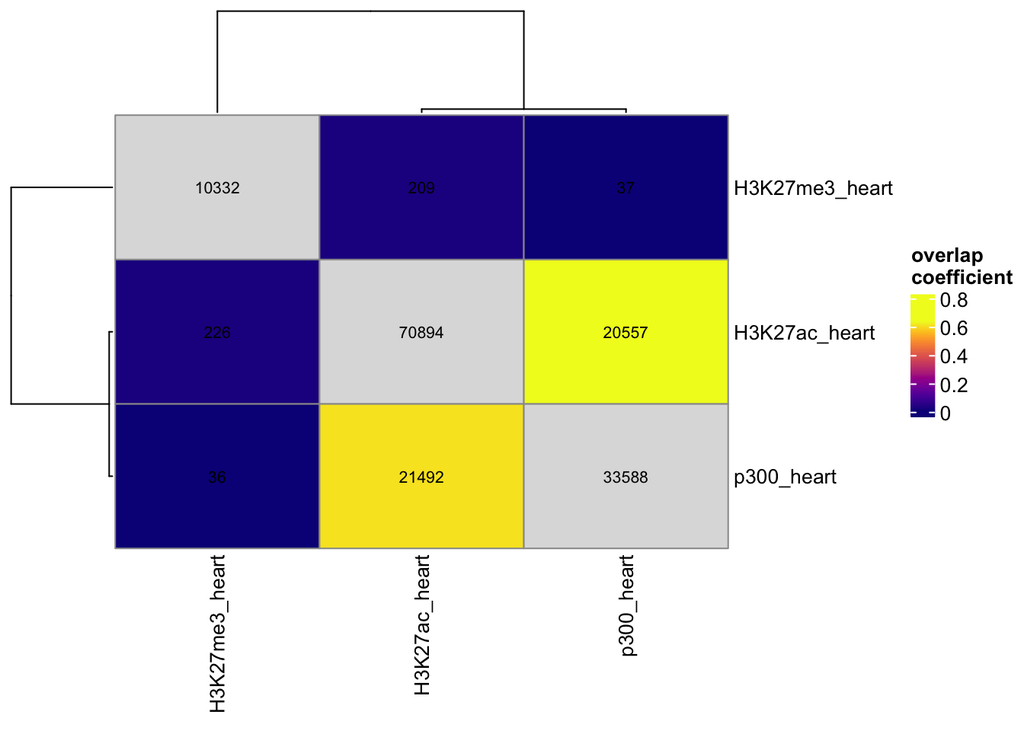

```r
#subset peaks by element names
peaks_heart <- peaks[c("H3K27ac_heart", "H3K27me3_heart", "p300_heart")]
peaks_mESC <- peaks[c("H3K27ac_mESC", "H3K27me3_mESC", "p300_mESC")]

regionOverlaps(peaks_heart)
```

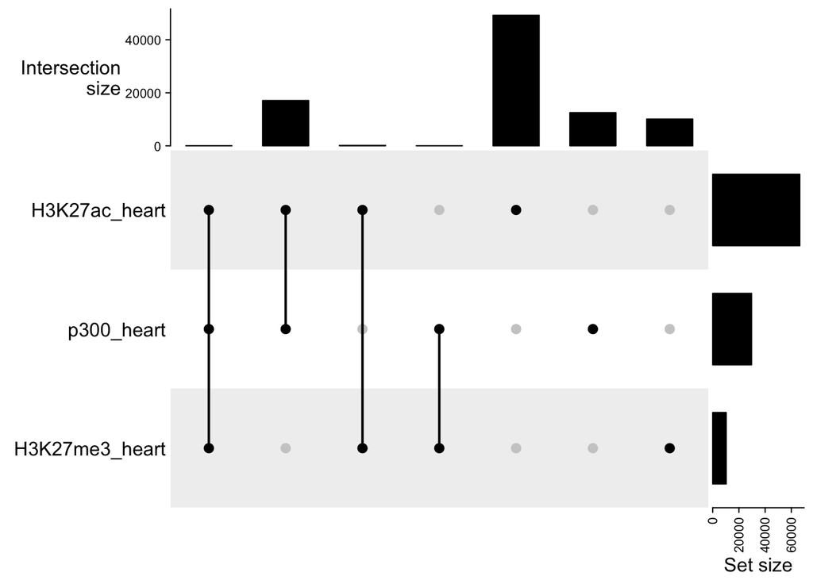

```r
UpSet(make_comb_mat(regionsToUpset(peaks_heart, nsets=length(peaks_heart))))
```

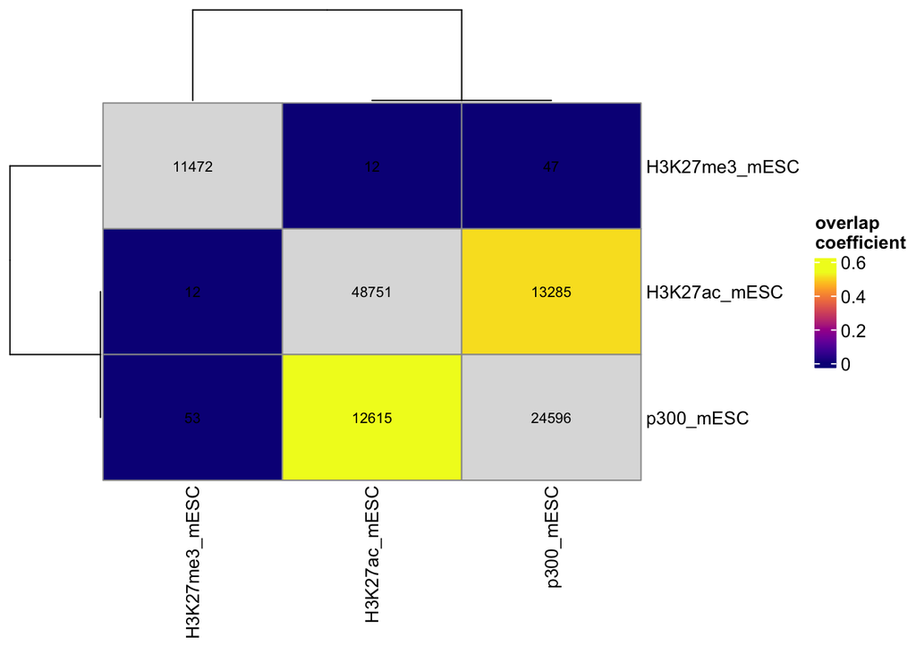

```r
regionOverlaps(peaks_mESC)
```

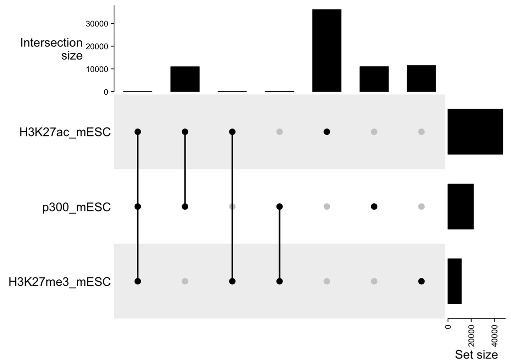

```r
UpSet(make_comb_mat(regionsToUpset(peaks_mESC, nsets=length(peaks_heart))))
```

### 3. What is the relationship between regulatory elements active in mESC and in the differentiated tissue?

### How many mESC peaks have been conserved in Heart?

```r
mESC_in_heart_ac <- sum(overlapsAny(peaks$H3K27ac_mESC, peaks$H3K27ac_heart))
mESC_in_heart_me3 <- sum(overlapsAny(peaks$H3K27me3_mESC, peaks$H3K27me3_heart))
mESC_in_heart_p300 <- sum(overlapsAny(peaks$p300_mESC, peaks$p300_heart))
cat ("How many H3K27ac peaks of mESC remain conserved till differentiated heart?", round(mESC_in_heart_ac/length(peaks$H3K27ac_mESC)*100), "% \n")
cat ("How many H3K27me3 peaks of mESC remain conserved till differentiated heart?", round(mESC_in_heart_me3/length(peaks$H3K27me3_mESC)*100), "% \n")
cat ("How many p300 peak of mESC remain conserved till differentiated heart?", round(mESC_in_heart_p300/length(peaks$p300_mESC)*100), "% \n")

cat ("Total H3K27ac_mESC peaks in mESC vs Heart: ", round(length(peaks$H3K27ac_mESC)), "vs", length(peaks$H3K27ac_heart), " \n")
cat ("Total H3K27me3_mESC peaks in mESC vs Heart: ", round(length(peaks$H3K27me3_mESC)), "vs", length(peaks$H3K27me3_heart), " \n")
```

```
## How many H3K27ac peaks of mESC remain conserved till differentiated heart? 27 %
## How many H3K27me3 peaks of mESC remain conserved till differentiated heart? 25 %
## How many p300 peak of mESC remain conserved till differentiated heart? 18 %
## Total H3K27ac_mESC peaks in mESC vs Heart:  48751 vs 70894
## Total H3K27me3_mESC peaks in mESC vs Heart:  11472 vs 10332
```